# Homework Unit 5: Resampling

Author

JIANGRAN GU

Published

February 17, 2026

## Introduction

In this assignment, you will select among model configurations using resampling methods. This includes training models with 2 different feature sets (specified in your recipe) and tuning hyperparameters (`k` in KNN).

## Set up

### Load required packages

```r
library(tidyverse)
library(tidymodels)
```

### Handle conflicts

```r
options(conflicts.policy = "depends.ok")
```

### Load in additional packages (only what you need)

```r
library(xfun, include.only = "cache_rds")
```

### Source function scripts (John’s or your own)

```r
source("https://github.com/jjcurtin/lab_support/blob/main/fun_ml.R?raw=true")
source("https://github.com/jjcurtin/lab_support/blob/main/fun_plots.R?raw=true")
source("https://github.com/jjcurtin/lab_support/blob/main/fun_eda.R?raw=true")
```

### Specify other global settings

Since we are going to use `cache_rds()`, we are also going to include `rerun_setting <- FALSE` in this chunk

```r
theme_set(theme_bw())
options(tibble.width = Inf, dplyr.print_max=Inf)
rerun_setting <- FALSE
```

### Paths

```r
path_data <- getwd()
```

### Set up parallel processing

Note you can type `cl` into your console to see how many cores your computer has.

```r
cl <- parallel::makePSOCKcluster(parallel::detectCores(logical = FALSE))
doParallel::registerDoParallel(cl)
```

## Read in data

Read in the `smoking_ema.csv` data file.  
Note you can set column types (`col_types = cols()`) or set `show_col_types = FALSE` if you don’t want the `read_csv()` output which is redundant with some of the `glimpse()` output!

```r
data_all <- read_csv(here::here(path_data, "smoking_ema.csv"))
```

Lets skim the data to check mins, maxs, and missing values.

```r
skim_all(data_all)
```

Data summary

| Name | data_all |
| --- | --- |
| Number of rows | 5876 |
| Number of columns | 13 |
| _______________________ |  |
| Column type frequency: |  |
| character | 1 |
| numeric | 12 |
| ________________________ |  |
| Group variables | None |

**Variable type: character**

| skim_variable | n_missing | complete_rate | min | max | empty | n_unique | whitespace |
| --- | --- | --- | --- | --- | --- | --- | --- |
| txt | 0 | 1 | 3 | 7 | 0 | 2 | 0 |

**Variable type: numeric**

| skim_variable | n_missing | complete_rate | mean | sd | p0 | p25 | p50 | p75 | p100 | skew | kurtosis |
| --- | --- | --- | --- | --- | --- | --- | --- | --- | --- | --- | --- |
| subid | 0 | 1 | 16226.50 | 5005.03 | 11011.00 | 11145.00 | 12142.00 | 21145.00 | 22149.00 | 0.14 | -1.94 |
| cigs | 0 | 1 | 0.18 | 0.39 | 0.00 | 0.00 | 0.00 | 0.00 | 1.00 | 1.64 | 0.67 |
| craving | 0 | 1 | 1.37 | 1.20 | 0.00 | 0.00 | 1.00 | 2.00 | 4.00 | 0.62 | -0.50 |
| anxious | 0 | 1 | 0.76 | 0.93 | 0.00 | 0.00 | 1.00 | 1.00 | 4.00 | 1.27 | 1.39 |
| irritable | 0 | 1 | 0.72 | 0.96 | 0.00 | 0.00 | 0.00 | 1.00 | 4.00 | 1.42 | 1.67 |
| sad | 0 | 1 | 0.44 | 0.82 | 0.00 | 0.00 | 0.00 | 1.00 | 4.00 | 2.18 | 4.83 |
| happy | 0 | 1 | 1.49 | 1.07 | 0.00 | 1.00 | 1.00 | 2.00 | 4.00 | 0.29 | -0.63 |
| stressful_event | 0 | 1 | 0.63 | 1.02 | 0.00 | 0.00 | 0.00 | 1.00 | 4.00 | 1.65 | 1.98 |
| positive_event | 0 | 1 | 0.85 | 1.07 | 0.00 | 0.00 | 0.00 | 2.00 | 4.00 | 1.08 | 0.22 |
| prior_cigs | 0 | 1 | 0.19 | 0.39 | 0.00 | 0.00 | 0.00 | 0.00 | 1.00 | 1.61 | 0.60 |
| lag | 0 | 1 | 6.96 | 5.39 | 0.09 | 3.42 | 6.06 | 9.31 | 108.00 | 4.03 | 42.02 |
| time_since_quit | 0 | 1 | 7.32 | 4.40 | 0.10 | 3.66 | 7.07 | 10.72 | 30.03 | 0.54 | 0.67 |

Next we are going to use the data dictionary to class variables  
We are doing this on the whole dataset prior to splitting it, so no need for a function (i.e., we are only using this code once!)

```r
valence_labels <- c("not at all", "mildly", "moderately", "very", "extremely")
event_labels <- c("no", "mild", "moderate", "very", "extreme")

data_all <- data_all |>
  mutate(cigs = factor(cigs, levels = 0:1, labels = c("no", "yes")),
         across(c(craving, anxious, irritable, sad, happy),
                ~ factor(.x, levels = 0:4, labels = valence_labels)),
         across(contains("_event"),
                ~ factor(.x, levels = 0:4, labels = event_labels)),
         txt = factor(txt, levels = c("placebo", "nrt")),
         prior_cigs = factor(prior_cigs, levels = 0:1, labels = c("no", "yes"))) |>
  glimpse()
```

```
Rows: 5,876
Columns: 13
$ subid           <dbl> 11011, 11011, 11011, 11011, 11011, 11011, 11011, 11011…
$ cigs            <fct> no, no, no, no, no, no, no, no, no, no, no, no, no, no…
$ craving         <fct> moderately, not at all, not at all, mildly, not at all…
$ anxious         <fct> not at all, moderately, not at all, not at all, not at…
$ irritable       <fct> mildly, not at all, not at all, not at all, very, mild…
$ sad             <fct> not at all, not at all, not at all, not at all, not at…
$ happy           <fct> not at all, not at all, very, moderately, moderately, …
$ stressful_event <fct> no, moderate, no, no, no, moderate, no, no, no, no, no…
$ positive_event  <fct> no, no, moderate, mild, no, mild, extreme, no, no, mil…
$ txt             <fct> nrt, nrt, nrt, nrt, nrt, nrt, nrt, nrt, nrt, nrt, nrt,…
$ prior_cigs      <fct> no, no, no, no, no, no, no, no, no, no, no, no, no, no…
$ lag             <dbl> 6.069444, 3.306389, 4.544444, 11.491111, 6.152222, 3.4…
$ time_since_quit <dbl> 0.6007639, 0.7385301, 0.9278819, 1.4066782, 1.6630208,…
```

Lets skim again to check our new variables

```r
skim_all(data_all)
```

Data summary

| Name | data_all |
| --- | --- |
| Number of rows | 5876 |
| Number of columns | 13 |
| _______________________ |  |
| Column type frequency: |  |
| factor | 10 |
| numeric | 3 |
| ________________________ |  |
| Group variables | None |

**Variable type: factor**

| skim_variable | n_missing | complete_rate | n_unique | top_counts |
| --- | --- | --- | --- | --- |
| cigs | 0 | 1.00 | 2 | no: 4798, yes: 1078 |
| craving | 71 | 0.99 | 5 | mil: 1766, not: 1669, mod: 1344, ver: 594 |
| anxious | 56 | 0.99 | 5 | not: 2913, mil: 1829, mod: 788, ver: 186 |
| irritable | 61 | 0.99 | 5 | not: 3131, mil: 1679, mod: 649, ver: 234 |
| sad | 35 | 0.99 | 5 | not: 4176, mil: 1081, mod: 380, ver: 130 |
| happy | 79 | 0.99 | 5 | mil: 1792, mod: 1779, not: 1203, ver: 827 |
| stressful_event | 0 | 1.00 | 5 | no: 3776, mil: 1057, mod: 620, ver: 264 |
| positive_event | 0 | 1.00 | 5 | no: 3108, mil: 1228, mod: 1006, ver: 401 |
| txt | 0 | 1.00 | 2 | nrt: 2983, pla: 2893 |
| prior_cigs | 0 | 1.00 | 2 | no: 4783, yes: 1093 |

**Variable type: numeric**

| skim_variable | n_missing | complete_rate | mean | sd | p0 | p25 | p50 | p75 | p100 | skew | kurtosis |
| --- | --- | --- | --- | --- | --- | --- | --- | --- | --- | --- | --- |
| subid | 0 | 1 | 16226.50 | 5005.03 | 11011.00 | 11145.00 | 12142.00 | 21145.00 | 22149.00 | 0.14 | -1.94 |
| lag | 0 | 1 | 6.96 | 5.39 | 0.09 | 3.42 | 6.06 | 9.31 | 108.00 | 4.03 | 42.02 |
| time_since_quit | 0 | 1 | 7.32 | 4.40 | 0.10 | 3.66 | 7.07 | 10.72 | 30.03 | 0.54 | 0.67 |

Hmm now we have missing data - Lets investigate

If we re-read in the raw data we can look at the different values for our factor variables

```r
data_all <- read_csv(here::here(path_data, "smoking_ema.csv"),
                     show_col_types = FALSE)

data_all |>
  select(craving:positive_event) |>
  map(janitor::tabyl)
```

```
$craving
   .x[[i]]    n      percent
 0.0000000 1669 0.2840367597
 0.5000000   16 0.0027229408
 0.6666667    1 0.0001701838
 0.7142857    1 0.0001701838
 0.7500000    1 0.0001701838
 1.0000000 1766 0.3005445882
 1.1666667    1 0.0001701838
 1.2500000    1 0.0001701838
 1.3000000    1 0.0001701838
 1.3333333    1 0.0001701838
 1.4000000    1 0.0001701838
 1.5000000   21 0.0035738598
 1.6000000    1 0.0001701838
 1.6666667    4 0.0006807352
 1.7500000    1 0.0001701838
 1.8333333    1 0.0001701838
 2.0000000 1344 0.2287270252
 2.3333333    1 0.0001701838
 2.5000000   12 0.0020422056
 2.6666667    1 0.0001701838
 3.0000000  594 0.1010891763
 3.3333333    2 0.0003403676
 3.5000000    3 0.0005105514
 4.0000000  432 0.0735194010

$anxious
   .x[[i]]    n      percent
 0.0000000 2913 0.4957454050
 0.3333333    4 0.0006807352
 0.5000000   16 0.0027229408
 0.7500000    1 0.0001701838
 1.0000000 1829 0.3112661675
 1.2000000    1 0.0001701838
 1.3333333    2 0.0003403676
 1.4000000    1 0.0001701838
 1.5000000   22 0.0037440436
 1.8333333    1 0.0001701838
 2.0000000  788 0.1341048332
```

[output cut: 66 more lines]

```
$stressful_event
 .x[[i]]    n    percent
       0 3776 0.64261402
       1 1057 0.17988428
       2  620 0.10551396
       3  264 0.04492852
       4  159 0.02705922

$positive_event
 .x[[i]]    n    percent
       0 3108 0.52893125
       1 1228 0.20898570
       2 1006 0.17120490
       3  401 0.06824370
       4  133 0.02263445
```

So now we see some of our ordinal variables have levels not in the data dictionary (i.e., they are not 0, 1, 2, 3, or 4).

What should we do? Are these errors that need to be corrected? Well thats up to you, the data scientist, to figure out! If you had access to the researchers who collected these data, you might start by discussing this with them. Otherwise, you may need to decide on your own how to proceed.

Some possibilities include, but are not limited to:

- Treat the real (non-integer) numbers as errors, set them to NA, and add a step in your recipe to impute them.
- Keep the variables in their raw numeric form.
- Round the variables to the nearest whole number and then convert to factor.

For example you could use the following code

```r
data_round <- data_all |>
  mutate(across(craving:happy, round))

data_round |>
  select(craving:happy) |>
  map(janitor::tabyl)
```

```
$craving
 .x[[i]]    n    percent
       0 1685 0.28675970
       1 1774 0.30190606
       2 1385 0.23570456
       3  597 0.10159973
       4  435 0.07402995

$anxious
 .x[[i]]    n    percent
       0 2933 0.49914908
       1 1834 0.31211709
       2  816 0.13886998
       3  187 0.03182437
       4  106 0.01803948

$irritable
 .x[[i]]    n    percent
       0 3159 0.53761062
       1 1684 0.28658952
       2  673 0.11453370
       3  236 0.04016338
       4  124 0.02110279

$sad
 .x[[i]]    n    percent
       0 4196 0.71409122
       1 1082 0.18413887
       2  392 0.06671205
       3  131 0.02229408
       4   75 0.01276378

$happy
 .x[[i]]    n    percent
       0 1222 0.20796460
       1 1799 0.30616065
       2 1829 0.31126617
       3  830 0.14125255
       4  196 0.03335602
```

There might be no right answer in cases like this and you have to make your best guess. Luckily, we know the people that collected this data. It turns out these scores were averaged across different survey responses and as a result non-integer numbers were introduced. Since, we know that these values are valid we are going to proceed by treating them as numeric variables in our models. We are still going to keep `stressful_event` and `positive_event` as ordinal variables since they have no non-integer values and class our other character variables as before.

```r
data_all <- data_all |>
  mutate(cigs = factor(cigs, levels = 0:1, labels = c("no", "yes")),
         across(contains("_event"),
                ~ factor(.x, levels = 0:4, labels = event_labels)),
         txt = factor(txt, levels = c("placebo", "nrt")),
         prior_cigs = factor(prior_cigs, levels = 0:1, labels = c("no", "yes"))) |>
  glimpse()
```

```
Rows: 5,876
Columns: 13
$ subid           <dbl> 11011, 11011, 11011, 11011, 11011, 11011, 11011, 11011…
$ cigs            <fct> no, no, no, no, no, no, no, no, no, no, no, no, no, no…
$ craving         <dbl> 2, 0, 0, 1, 0, 2, 2, 0, 0, 1, 1, 0, 1, 1, 1, 0, 0, 4, …
$ anxious         <dbl> 0, 2, 0, 0, 0, 1, 0, 0, 0, 0, 0, 0, 0, 0, 0, 0, 0, 0, …
$ irritable       <dbl> 1.0, 0.0, 0.0, 0.0, 3.0, 1.0, 0.0, 0.0, 0.0, 0.0, 0.0,…
$ sad             <dbl> 0, 0, 0, 0, 0, 0, 0, 0, 0, 0, 0, 0, 0, 0, 0, 0, 0, 0, …
$ happy           <dbl> 0.0, 0.0, 3.0, 2.0, 2.0, 1.0, 4.0, 3.0, 3.0, 2.0, 3.0,…
$ stressful_event <fct> no, moderate, no, no, no, moderate, no, no, no, no, no…
$ positive_event  <fct> no, no, moderate, mild, no, mild, extreme, no, no, mil…
$ txt             <fct> nrt, nrt, nrt, nrt, nrt, nrt, nrt, nrt, nrt, nrt, nrt,…
$ prior_cigs      <fct> no, no, no, no, no, no, no, no, no, no, no, no, no, no…
$ lag             <dbl> 6.069444, 3.306389, 4.544444, 11.491111, 6.152222, 3.4…
$ time_since_quit <dbl> 0.6007639, 0.7385301, 0.9278819, 1.4066782, 1.6630208,…
```

Lets skim the data one more time to be sure everything looks good.

```r
data_all |>
  skim_some()
```

Data summary

| Name | data_all |
| --- | --- |
| Number of rows | 5876 |
| Number of columns | 13 |
| _______________________ |  |
| Column type frequency: |  |
| factor | 5 |
| numeric | 8 |
| ________________________ |  |
| Group variables | None |

**Variable type: factor**

| skim_variable | n_missing | complete_rate | ordered | n_unique | top_counts |
| --- | --- | --- | --- | --- | --- |
| cigs | 0 | 1 | FALSE | 2 | no: 4798, yes: 1078 |
| stressful_event | 0 | 1 | FALSE | 5 | no: 3776, mil: 1057, mod: 620, ver: 264 |
| positive_event | 0 | 1 | FALSE | 5 | no: 3108, mil: 1228, mod: 1006, ver: 401 |
| txt | 0 | 1 | FALSE | 2 | nrt: 2983, pla: 2893 |
| prior_cigs | 0 | 1 | FALSE | 2 | no: 4783, yes: 1093 |

**Variable type: numeric**

| skim_variable | n_missing | complete_rate | p0 | p100 |
| --- | --- | --- | --- | --- |
| subid | 0 | 1 | 11011.00 | 22149.00 |
| craving | 0 | 1 | 0.00 | 4.00 |
| anxious | 0 | 1 | 0.00 | 4.00 |
| irritable | 0 | 1 | 0.00 | 4.00 |
| sad | 0 | 1 | 0.00 | 4.00 |
| happy | 0 | 1 | 0.00 | 4.00 |
| lag | 0 | 1 | 0.09 | 108.00 |
| time_since_quit | 0 | 1 | 0.10 | 30.03 |

## Part 1: Selecting among model configurations with k-fold cross-validation

### Split data

Split your data into 10 folds, stratified on `cigs`. Don’t forget to set a seed!

```r
set.seed(20060328)
splits_kfold <- data_all |>
  vfold_cv(v = 10, repeats = 1, strata = "cigs")
splits_kfold
```

```
#  10-fold cross-validation using stratification
# A tibble: 10 × 2
   splits             id
   <list>             <chr>
 1 <split [5288/588]> Fold01
 2 <split [5288/588]> Fold02
 3 <split [5288/588]> Fold03
 4 <split [5288/588]> Fold04
 5 <split [5288/588]> Fold05
 6 <split [5288/588]> Fold06
 7 <split [5288/588]> Fold07
 8 <split [5288/588]> Fold08
 9 <split [5290/586]> Fold09
10 <split [5290/586]> Fold10
```

### Feature Set 1

Build a recipe with the following specifications:

- Use `cigs` as the outcome variable regressed on `craving`.
- Set up the outcome as a factor with the positive class (“yes”) as the second level.
- Use craving as a feature by simply transforming this ordinal predictor to numeric based on the order of its scores.

*Note we already set our outcome variable up as factor with positive class as second level when we classed our data so we aren’t repeating that here. Also we have decided to keep craving as a numeric variable so we don’t have to do any manipulations here either.*

```r
rec <- recipe(cigs ~ craving, data = data_all)
```

As a double check you can `prep` and `bake` your recipe on the full data set to see if the variables look correct.

```r
rec_prep <- rec |>
  prep(data_all)

feat_all <- rec_prep |>
  bake(NULL)
```

Fit the model with k-fold cross-validation. Use logistic regression as your statistical algorithm, `rec_kfold_1` as your recipe, and `accuracy` as your metric.

```r
fit <-
  logistic_reg()|>
  set_engine("glm")|>
  fit_resamples(preprocessor = rec, resamples = splits_kfold, metrics = metric_set(accuracy))
```

We are going to also use `cache_rds` as we fit our models. *Hint: wrap your `fit_resamples()` call inside `cache_rds(expr = { ... }, dir = "cache/", file = "meaningful_name", rerun = rerun_setting)`. See the web book for an example.*

```r
rerun_setting <- FALSE
```

```r
fit <- cache_rds(
  expr = {
      logistic_reg()|>
  set_engine("glm")|>
  fit_resamples(preprocessor = rec, resamples = splits_kfold, metrics = metric_set(accuracy))
  },
  dir = "cache/001",
  file = "fit",
  rerun = rerun_setting
)
```

Examine performance estimates. Use the `collect_metrics()` function to make a table of the held-out performance estimates from the 10 folds.

```r
metrics <- collect_metrics(fit, summarize = FALSE)
metrics |> print_kbl()
```

| id | .metric | .estimator | .estimate | .config |
| --- | --- | --- | --- | --- |
| Fold01 | accuracy | binary | 0.82 | pre0_mod0_post0 |
| Fold02 | accuracy | binary | 0.82 | pre0_mod0_post0 |
| Fold03 | accuracy | binary | 0.82 | pre0_mod0_post0 |
| Fold04 | accuracy | binary | 0.82 | pre0_mod0_post0 |
| Fold05 | accuracy | binary | 0.82 | pre0_mod0_post0 |
| Fold06 | accuracy | binary | 0.82 | pre0_mod0_post0 |
| Fold07 | accuracy | binary | 0.82 | pre0_mod0_post0 |
| Fold08 | accuracy | binary | 0.82 | pre0_mod0_post0 |
| Fold09 | accuracy | binary | 0.82 | pre0_mod0_post0 |
| Fold10 | accuracy | binary | 0.82 | pre0_mod0_post0 |

Plot a histogram of the performance estimates. *Hint: you can use `plot_hist()` from `fun_plots.R`.*

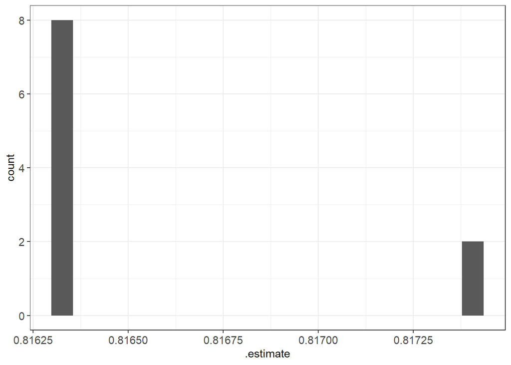

```r
metrics |> plot_hist(".estimate", bins = 20)
```

Print the average performance over folds with the `summarize = TRUE` argument.

```r
collect_metrics(fit, summarize = TRUE)
```

```
# A tibble: 1 × 6
  .metric  .estimator  mean     n  std_err .config
  <chr>    <chr>      <dbl> <int>    <dbl> <chr>
1 accuracy binary     0.817    10 0.000144 pre0_mod0_post0
```

### Feature Set 2

Build a second recipe with the following specifications:

- Use `cigs` as the outcome variable regressed on all variables.
- Set up the outcome as a factor with the positive class (“yes”) as the second level.
- Set up other variables as factors where needed.
- Apply dummy coding.
- Create an interaction between `stressful_event` and `lag`.
- Remove the `subid` variable with `step_rm()`

*Note we already classed our character variables as factors when we read the data in so we don’t need to do this again*

```r
rec <- recipe(cigs ~ ., data = data_all)
```

Again check that your recipe is creating features how you expect it should.

```r
rec_prep <- rec |>
  prep(data_all)

feat_all <- rec_prep |>
  bake(NULL)
```

Fit the model with k-fold cross-validation. Use logistic regression as your statistical algorithm, `rec_kfold_2` as your recipe, and `accuracy` as your metric.

```r
fit <- cache_rds(
  expr = {
      logistic_reg()|>
  set_engine("glm")|>
  fit_resamples(preprocessor = rec, resamples = splits_kfold, metrics = metric_set(accuracy))
  },
  dir = "cache/002",
  file = "fit",
  rerun = rerun_setting
)
```

Examine performance estimates. Use the `collect_metrics()` function to make a table of the held-out performance estimates.

```r
metrics <- collect_metrics(fit, summarize = FALSE)
metrics |> print_kbl()
```

| id | .metric | .estimator | .estimate | .config |
| --- | --- | --- | --- | --- |
| Fold01 | accuracy | binary | 0.84 | pre0_mod0_post0 |
| Fold02 | accuracy | binary | 0.85 | pre0_mod0_post0 |
| Fold03 | accuracy | binary | 0.87 | pre0_mod0_post0 |
| Fold04 | accuracy | binary | 0.87 | pre0_mod0_post0 |
| Fold05 | accuracy | binary | 0.85 | pre0_mod0_post0 |
| Fold06 | accuracy | binary | 0.86 | pre0_mod0_post0 |
| Fold07 | accuracy | binary | 0.86 | pre0_mod0_post0 |
| Fold08 | accuracy | binary | 0.87 | pre0_mod0_post0 |
| Fold09 | accuracy | binary | 0.85 | pre0_mod0_post0 |
| Fold10 | accuracy | binary | 0.86 | pre0_mod0_post0 |

Plot a histogram of the performance estimates.

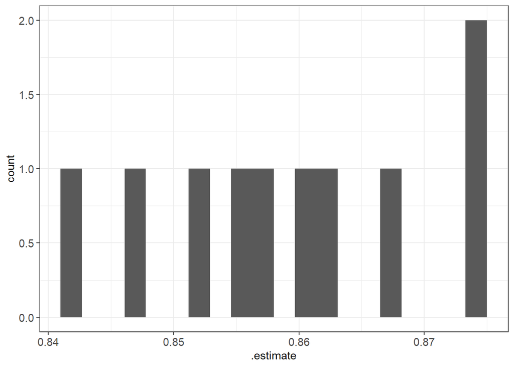

```r
metrics |> plot_hist(".estimate", bins = 20)
```

Print the average performance over folds with the `summarize = TRUE` argument.

```r
collect_metrics(fit, summarize = TRUE)
```

```
# A tibble: 1 × 6
  .metric  .estimator  mean     n std_err .config
  <chr>    <chr>      <dbl> <int>   <dbl> <chr>
1 accuracy binary     0.859    10 0.00341 pre0_mod0_post0
```

### Selecting the best model configuration

Looking back at your two average performance estimates (one from each feature set), which model configuration would you select and why?

Feature Set 2 is better because it achieved a higher average cross-validated accuracy compared to Feature Set 1, indicating better generalization performance.

## Part 2: Tuning hyperparameters with bootstrap resampling

### Split data

Split your data using bootstrap. Stratify on `cigs` and use 100 bootstraps. Don’t forget to set a seed!

```r
set.seed(20060328)
splits <- data_all |>
  bootstraps(times = 100, strata = "cigs")
splits
```

```
# Bootstrap sampling using stratification
# A tibble: 100 × 2
    splits              id
    <list>              <chr>
  1 <split [5876/2151]> Bootstrap001
  2 <split [5876/2118]> Bootstrap002
  3 <split [5876/2158]> Bootstrap003
  4 <split [5876/2141]> Bootstrap004
  5 <split [5876/2240]> Bootstrap005
  6 <split [5876/2137]> Bootstrap006
  7 <split [5876/2172]> Bootstrap007
  8 <split [5876/2150]> Bootstrap008
  9 <split [5876/2150]> Bootstrap009
 10 <split [5876/2220]> Bootstrap010
 11 <split [5876/2166]> Bootstrap011
```

[output cut: 89 more lines]

### Set up hyperparameter grid

Create a tibble with all values of the hyperparameter (`k`) you will consider. Remember that this dataset has a lot of observations in it (~6000), so starting with some higher k-values than we’re used to testing may be helpful.

```r
hyper_grid <- expand.grid(neighbors = seq(25, 500, by = 10))
hyper_grid
```

```
   neighbors
1         25
2         35
3         45
4         55
5         65
6         75
7         85
8         95
9        105
10       115
11       125
12       135
13       145
14       155
```

[output cut: 34 more lines]

### Feature Set 1

Build a recipe with the following specifications:

- Use `cigs` as the outcome variable regressed on `craving`.
- Set up the outcome as a factor with the positive class (“yes”) as the second level.
- Use the same numeric transformation of craving as before

This is the same recipe as earlier so you can just re-assign it here (e.g., `rec_boot_1 <- rec_kfold_1`). Also remember even though this is going to be used in a KNN model, we don’t have to scale or range correct if there is only one predictor!

```r
rec <- recipe(cigs ~ craving, data = data_all)
```

Tune the model with bootstrapping for cross-validation. Use KNN classification as your statistical algorithm, `rec_boot_1` as your recipe, `hyper_grid` as your tuning grid, and `accuracy` as your metric. *Hint: use `tune_grid()` instead of `fit_resamples()`, and specify `neighbors = tune()` in your algorithm. Don’t forget to pass `grid = hyper_grid`.*

```r
fits_knn_boot <- cache_rds(
  expr = {
    nearest_neighbor(neighbors = tune())|>
      set_engine("kknn")|>
      set_mode("classification")|>
      tune_grid(preprocessor = rec,
                resamples = splits,
                grid = hyper_grid,
                metrics = metric_set(accuracy))
  },
  dir = "cache/003/",
  file = "fits_knn_boot",
  rerun = rerun_setting
)
```

Examine performance estimates across the OOB held-out sets. Remember that you will now see one estimate per hyperparameter value, averaged across bootstraps.

```r
metrics <- collect_metrics(fits_knn_boot)
metrics
```

```
# A tibble: 48 × 7
   neighbors .metric  .estimator  mean     n  std_err .config
       <dbl> <chr>    <chr>      <dbl> <int>    <dbl> <chr>
 1        25 accuracy binary     0.816   100 0.000404 pre0_mod01_post0
 2        35 accuracy binary     0.816   100 0.000403 pre0_mod02_post0
 3        45 accuracy binary     0.817   100 0.000405 pre0_mod03_post0
 4        55 accuracy binary     0.817   100 0.000405 pre0_mod04_post0
 5        65 accuracy binary     0.817   100 0.000405 pre0_mod05_post0
 6        75 accuracy binary     0.817   100 0.000405 pre0_mod06_post0
 7        85 accuracy binary     0.817   100 0.000405 pre0_mod07_post0
 8        95 accuracy binary     0.817   100 0.000405 pre0_mod08_post0
 9       105 accuracy binary     0.817   100 0.000405 pre0_mod09_post0
10       115 accuracy binary     0.817   100 0.000405 pre0_mod10_post0
11       125 accuracy binary     0.817   100 0.000405 pre0_mod11_post0
12       135 accuracy binary     0.817   100 0.000405 pre0_mod12_post0
```

[output cut: 36 more lines]

Plot the average performance by hyperparameter value. *Hint: you can use `plot_hyperparameters()` from `fun_ml.R`, specifying `hp1` and `metric` arguments.*

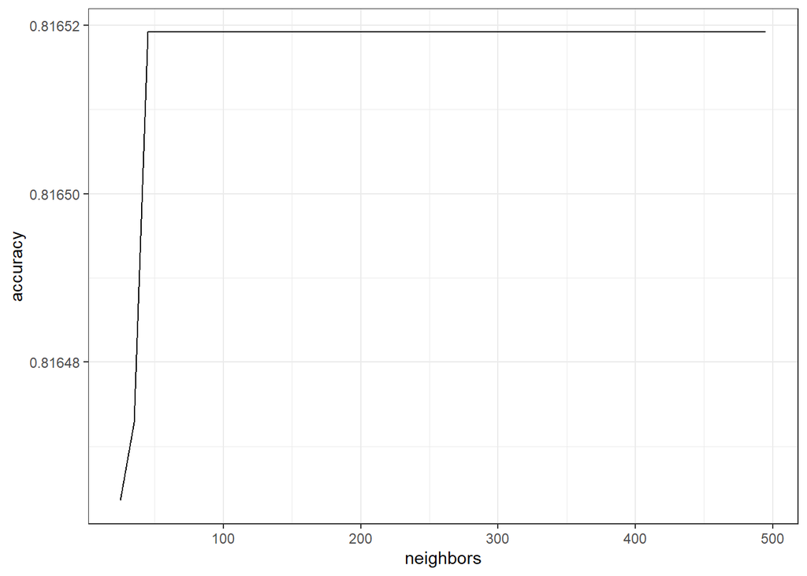

```r
plot_hyperparameters(
  fits_knn_boot,
  hp1 = "neighbors",
  metric = "accuracy"
)
```

Comment on what you see in the hyperparameter plot. Does performance change across values of k? What might this tell you about the model?

Print the performance of your best model configuration with the `show_best()` function.

```r
show_best(fits_knn_boot)
```

```
# A tibble: 5 × 7
  neighbors .metric  .estimator  mean     n  std_err .config
      <dbl> <chr>    <chr>      <dbl> <int>    <dbl> <chr>
1        45 accuracy binary     0.817   100 0.000405 pre0_mod03_post0
2        55 accuracy binary     0.817   100 0.000405 pre0_mod04_post0
3        65 accuracy binary     0.817   100 0.000405 pre0_mod05_post0
4        75 accuracy binary     0.817   100 0.000405 pre0_mod06_post0
5        85 accuracy binary     0.817   100 0.000405 pre0_mod07_post0
```

### Feature Set 2

Build a second recipe with the following specifications:

- Use `cigs` as the outcome variable regressed on all variables.
- Set up the outcome as a factor with the positive class (“yes”) as the second level.
- Set up other variables as factors where needed.
- Apply dummy coding.
- Create an interaction between `stressful_event` and `lag`.
- Remove the `subid` variable with `step_rm()`
- **Take appropriate scaling steps for features to be able to fit KNN requirements.** *Hint: you can build on `rec_kfold_2` and add `step_range(all_numeric_predictors())` for range correction.*

```r
data_all <- data_all |>
  mutate(
    across(where(is.character),factor)
  )
```

```r
rec <- recipe(cigs ~ ., data = data_all) |>
  step_interact( ~
                   stressful_event:lag)|>
  step_rm(subid)|>
  step_range(all_numeric_predictors())|>
  step_dummy(all_nominal_predictors())
```

Tune the model with bootstrapping for cross-validation. Use KNN classification as your statistical algorithm, `rec_boot_2` as your recipe, `hyper_grid` as your tuning grid, and `accuracy` as your metric.

```r
rec <- cache_rds(
  expr = {
    nearest_neighbor(neighbors = tune())|>
      set_engine("kknn")|>
      set_mode("classification")|>
      tune_grid(preprocessor = rec,
                resamples = splits,
                grid = hyper_grid,
                metrics = metric_set(accuracy))
  },
  dir = "cache/004/",
  file = "fits_knn_boot",
  rerun = rerun_setting
)
```

Examine performance estimates. Remember that you will now see one estimate per hyperparameter value, averaged across bootstraps.

```r
metrics <- collect_metrics(fits_knn_boot)
metrics
```

```
# A tibble: 48 × 7
   neighbors .metric  .estimator  mean     n  std_err .config
       <dbl> <chr>    <chr>      <dbl> <int>    <dbl> <chr>
 1        25 accuracy binary     0.816   100 0.000404 pre0_mod01_post0
 2        35 accuracy binary     0.816   100 0.000403 pre0_mod02_post0
 3        45 accuracy binary     0.817   100 0.000405 pre0_mod03_post0
 4        55 accuracy binary     0.817   100 0.000405 pre0_mod04_post0
 5        65 accuracy binary     0.817   100 0.000405 pre0_mod05_post0
 6        75 accuracy binary     0.817   100 0.000405 pre0_mod06_post0
 7        85 accuracy binary     0.817   100 0.000405 pre0_mod07_post0
 8        95 accuracy binary     0.817   100 0.000405 pre0_mod08_post0
 9       105 accuracy binary     0.817   100 0.000405 pre0_mod09_post0
10       115 accuracy binary     0.817   100 0.000405 pre0_mod10_post0
11       125 accuracy binary     0.817   100 0.000405 pre0_mod11_post0
12       135 accuracy binary     0.817   100 0.000405 pre0_mod12_post0
```

[output cut: 36 more lines]

Plot the average performance by hyperparameter value.

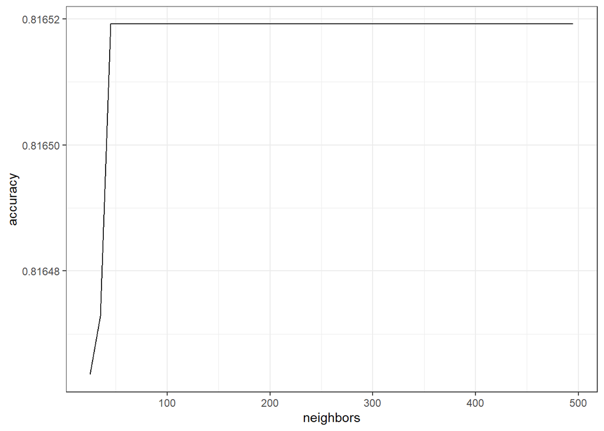

```r
plot_hyperparameters(
  fits_knn_boot,
  hp1 = "neighbors",
  metric = "accuracy"
)
```

Comment on what you see in the hyperparameter plot. Does the plot suggest you’ve considered a sufficient range of k-values?

Print the performance of your best model configuration with the `show_best()` function.

```r
show_best(fits_knn_boot)
```

```
# A tibble: 5 × 7
  neighbors .metric  .estimator  mean     n  std_err .config
      <dbl> <chr>    <chr>      <dbl> <int>    <dbl> <chr>
1        45 accuracy binary     0.817   100 0.000405 pre0_mod03_post0
2        55 accuracy binary     0.817   100 0.000405 pre0_mod04_post0
3        65 accuracy binary     0.817   100 0.000405 pre0_mod05_post0
4        75 accuracy binary     0.817   100 0.000405 pre0_mod06_post0
5        85 accuracy binary     0.817   100 0.000405 pre0_mod07_post0
```

## Part 3: Selecting among model configurations with grouped k-fold cross-validation

In the final part of this assignment, you will use grouped k-fold cross-validation to match the data structure.

### Split data

Split your data into 10 folds using the `group_vfold_cv()` function. Use the grouping argument (`group = "subid"`).

For this example, we asked you to not stratify on `cigs`. As a note, if you ever want to stratify on your outcome (e.g., `cigs`) within a grouping variable (e.g., `subid`), you need to create a new variable capturing the distribution of the outcome within each subject (in this case, the mean number of positive cases of `cigs` within each subject). This allows the splitting to attempt to assign different `subid` groups to analysis and assessment sets within each fold in combinations that will yield roughly the same proportion of positive cases on the outcome across all folds.

Try implementing this approach below. You will need to:

1. Create a new `strata` variable that captures the proportion of positive cases of `cigs` within each `subid` (hint: `group_by(subid)`, then `mutate()` with `mean(as.numeric(cigs))`, then `ungroup()`)
2. Use `group_vfold_cv()` with `group = "subid"`, `v = 10`, `repeats = 1`, and `strata = "strata"`

Don’t forget to set a seed!

```r
data_all <- data_all |>
  group_by(subid)|>
  mutate(
    strata = mean(as.numeric(cigs))
  )|>
  ungroup()
```

```r
set.seed(20060328)
splits <- group_vfold_cv(group = "subid", v = 10, repeats = 1, strata = "strata", data = data_all)
```

### Feature Set 1

Fit the first set of models with grouped k-fold cross-validation. Use logistic regression as your statistical algorithm, `rec_kfold_1` as your recipe (doesn’t need to change from above!), and `accuracy` as your metric.

```r
rec <- recipe(cigs ~ craving, data = data_all)
fit <-
  logistic_reg()|>
  set_engine("glm")|>
  fit_resamples(preprocessor = rec, resamples = splits, metrics = metric_set(accuracy))
```

Examine performance estimates on held out samples.

```r
metrics <- collect_metrics(fit, summarize = FALSE)
metrics |> print_kbl()
```

| id | .metric | .estimator | .estimate | .config |
| --- | --- | --- | --- | --- |
| Resample01 | accuracy | binary | 0.86 | pre0_mod0_post0 |
| Resample02 | accuracy | binary | 0.82 | pre0_mod0_post0 |
| Resample03 | accuracy | binary | 0.66 | pre0_mod0_post0 |
| Resample04 | accuracy | binary | 0.96 | pre0_mod0_post0 |
| Resample05 | accuracy | binary | 0.74 | pre0_mod0_post0 |
| Resample06 | accuracy | binary | 0.84 | pre0_mod0_post0 |
| Resample07 | accuracy | binary | 0.86 | pre0_mod0_post0 |
| Resample08 | accuracy | binary | 0.82 | pre0_mod0_post0 |
| Resample09 | accuracy | binary | 0.86 | pre0_mod0_post0 |
| Resample10 | accuracy | binary | 0.74 | pre0_mod0_post0 |

Plot a histogram of the performance estimates.

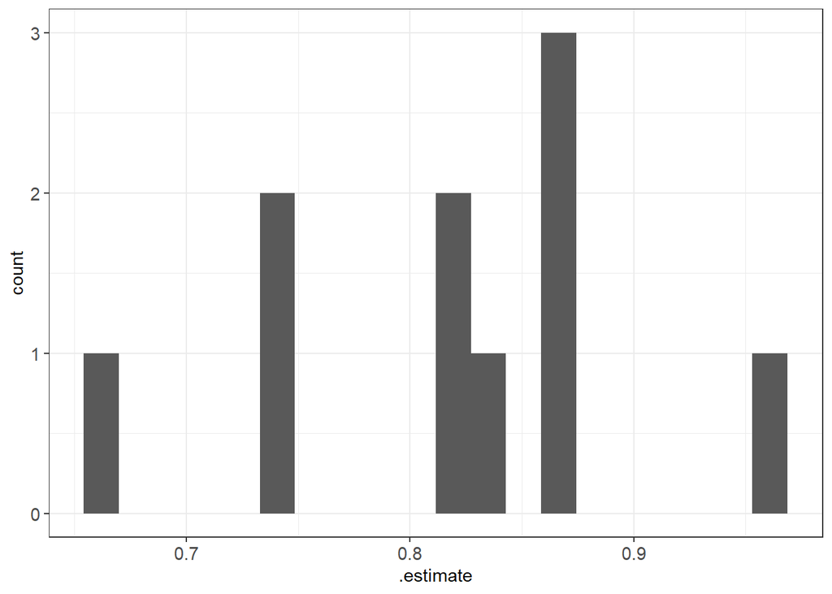

```r
metrics |> plot_hist(".estimate", bins = 20)
```

Print the average performance over folds with the `summarize = TRUE` argument.

```r
collect_metrics(fit, summarize = TRUE)
```

```
# A tibble: 1 × 6
  .metric  .estimator  mean     n std_err .config
  <chr>    <chr>      <dbl> <int>   <dbl> <chr>
1 accuracy binary     0.817    10  0.0263 pre0_mod0_post0
```

### Feature Set 2

Fit the second model with grouped k-fold cross-validation. Use logistic regression as your statistical algorithm, `rec_kfold_2` as your recipe (doesn’t need to change from above!), and `accuracy` as your metric.

```r
rec <- recipe(cigs ~ ., data = data_all)
fit <-
  logistic_reg()|>
  set_engine("glm")|>
  fit_resamples(preprocessor = rec, resamples = splits, metrics = metric_set(accuracy))
```

Examine performance estimates on held out samples.

```r
metrics <- collect_metrics(fit, summarize = FALSE)
metrics |> print_kbl()
```

| id | .metric | .estimator | .estimate | .config |
| --- | --- | --- | --- | --- |
| Resample01 | accuracy | binary | 0.93 | pre0_mod0_post0 |
| Resample02 | accuracy | binary | 0.93 | pre0_mod0_post0 |
| Resample03 | accuracy | binary | 0.82 | pre0_mod0_post0 |
| Resample04 | accuracy | binary | 0.96 | pre0_mod0_post0 |
| Resample05 | accuracy | binary | 0.84 | pre0_mod0_post0 |
| Resample06 | accuracy | binary | 0.88 | pre0_mod0_post0 |
| Resample07 | accuracy | binary | 0.86 | pre0_mod0_post0 |
| Resample08 | accuracy | binary | 0.87 | pre0_mod0_post0 |
| Resample09 | accuracy | binary | 0.92 | pre0_mod0_post0 |
| Resample10 | accuracy | binary | 0.85 | pre0_mod0_post0 |

Plot a histogram of the performance estimates.

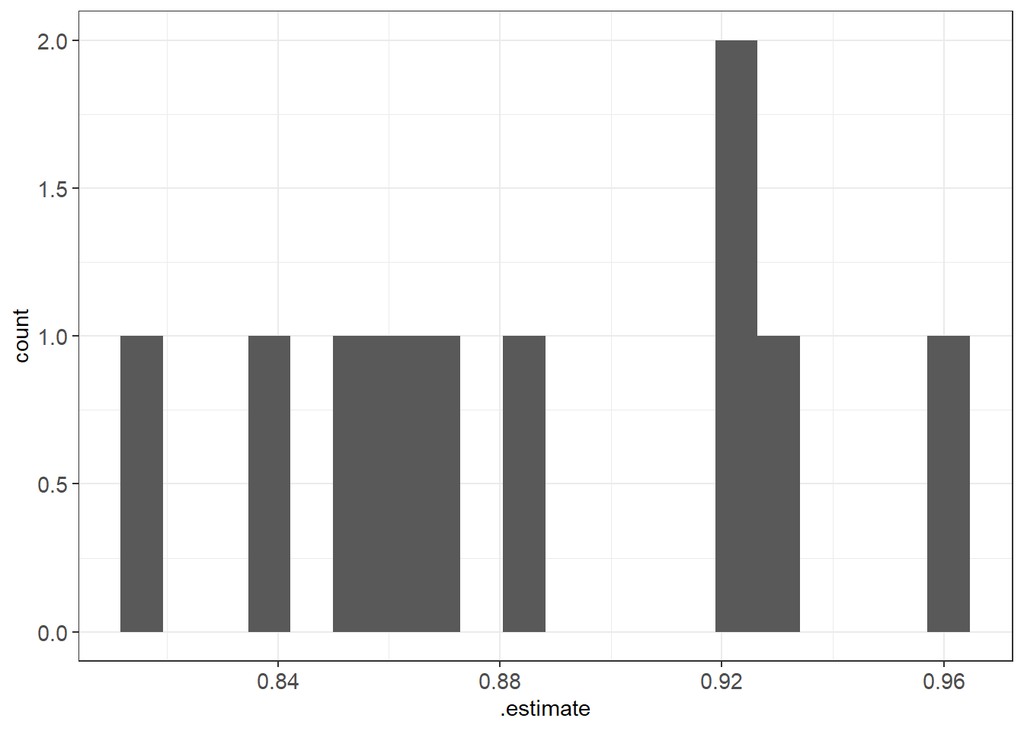

```r
metrics |> plot_hist(".estimate", bins = 20)
```

Print the average performance over folds with the `summarize = TRUE` argument.

```r
collect_metrics(fit, summarize = TRUE)
```

```
# A tibble: 1 × 6
  .metric  .estimator  mean     n std_err .config
  <chr>    <chr>      <dbl> <int>   <dbl> <chr>
1 accuracy binary     0.886    10  0.0148 pre0_mod0_post0
```

### Selecting the best model configuration

Looking back at your two average performance estimates (one from each feature set), which model configuration would you select and why?

**Remember, once your best model is chosen and evaluated you would then want to refit it once on all the data before deploying it for use!**

## Save, Render, Upload

### Save

Save this `.qmd` file with your last name at the end (e.g., `hw_unit_05_resampling_punturieri.qmd`). Make sure you changed “Your Name” at the top of the file to be your own name.

### Render

Render the file to html and upload !ONLY! your rendered html file to Canvas.